# KKH_forecast_realattempt

KKH

2024-02-29

WILL NEED TO INSTALL TIDYMODELS AND THE MGCV PACKAGE IN DOCKER!!! - DONE

GO TO GITHUB, CLICK ON DRAFT PDF YML AND DELETE IT!!!

```r
#read in the targets data
targets <- read_csv('https://data.ecoforecast.org/neon4cast-targets/aquatics/aquatics-targets.csv.gz')

# read in the sites data
aquatic_sites <- read_csv("https://raw.githubusercontent.com/eco4cast/neon4cast-targets/main/NEON_Field_Site_Metadata_20220412.csv") |>
  dplyr::filter(aquatics == 1)

lake_sites <- aquatic_sites %>%
  filter(field_site_subtype == 'Lake')

url <- "https://sdsc.osn.xsede.org/bio230014-bucket01/challenges/supporting_data/project_id=neon4cast/aquatics-expanded-observations.csv.gz"

lake_depths <- read_csv(url, show_col_types = FALSE)

# Filter the targets
targets <- targets %>%
  filter(site_id %in% lake_sites$field_site_id,
         variable == 'temperature')
```

This is where you could change or add meteorological variables that are used to predict the target

Other variable names can be found at https://projects.ecoforecast.org/neon4cast-docs/Shared-Forecast-Drivers.html#stage-3

Variable names: air_temperature (K) air_pressure (Pa) relative_humidity (proportion) surface_downwelling_longwave_flux_in_air (W/m^2) surface_downwelling_shortwave_flux_in_air (W/m^2) precipitation_flux (kg/(m^2 s)) eastward_wind (m/s) northward_wind (m/s)

```r
met_variables <- c("air_temperature", "precipitation_flux", "eastward_wind", "northward_wind", "air_pressure")
# variables <- c("air_temperature", "precipitation_flux")
```

Get NOAA past forecasts for model building and testing. Past forecasts are available starting 2020-09-24

```r
# Past stacked weather
noaa_past_s3 <- neon4cast::noaa_stage3()

noaa_past <- noaa_past_s3  |>
  dplyr::filter(site_id %in% lake_sites$field_site_id,
                datetime >= ymd('2017-01-01'),
                variable %in% met_variables) |>
  dplyr::collect()

# aggregate the past to mean values
noaa_past_mean <- noaa_past |>
  mutate(datetime = as_date(datetime)) |>
  group_by(datetime, site_id, variable) |>
  summarize(prediction = mean(prediction, na.rm = TRUE), .groups = "drop") |>
  # convert air temperature to Celsius if it is included in the weather data
  mutate(prediction = ifelse(variable == "air_temperature", prediction - 273.15, prediction)) |>
  pivot_wider(names_from = variable, values_from = prediction)
```

Let’s look at some variables and consider some correlations. NOAA data

```r
noaa_past_mean_cor <- noaa_past_mean[, c(3,4,5,6,7)]
cor_matrix <- round(cor(noaa_past_mean_cor), 2)
head(cor_matrix)
```

```
##                    air_pressure air_temperature eastward_wind northward_wind
## air_pressure               1.00            0.65         -0.22          -0.09
## air_temperature            0.65            1.00          0.01          -0.18
## eastward_wind             -0.22            0.01          1.00          -0.16
## northward_wind            -0.09           -0.18         -0.16           1.00
## precipitation_flux         0.13            0.24         -0.06          -0.13
##                    precipitation_flux
## air_pressure                     0.13
## air_temperature                  0.24
## eastward_wind                   -0.06
## northward_wind                  -0.13
## precipitation_flux               1.00
```

```r
melted_cor_matrix <- melt(cor_matrix)
head(melted_cor_matrix)
```

```
##                 Var1            Var2 value
## 1       air_pressure    air_pressure  1.00
## 2    air_temperature    air_pressure  0.65
## 3      eastward_wind    air_pressure -0.22
## 4     northward_wind    air_pressure -0.09
## 5 precipitation_flux    air_pressure  0.13
## 6       air_pressure air_temperature  0.65
```

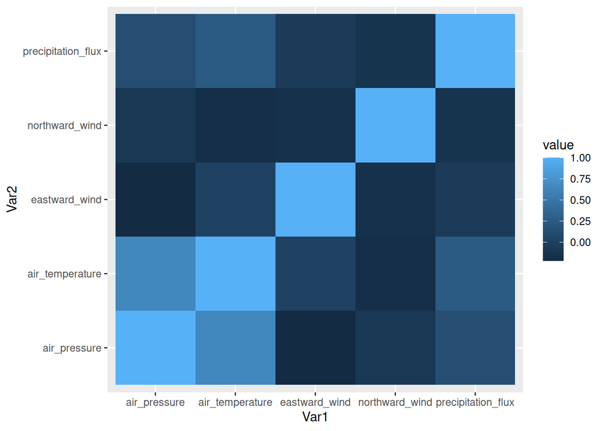

```r
ggplot(data = melted_cor_matrix, aes(x=Var1, y=Var2, fill=value)) +
  geom_tile()
```

Considering different model types! Non-parametric statistical models: splines, GAMs and Gaussian process regression, others? Autoregressive with up to ? day lags

Start by making an autoregressive model for temperature similar to mod 7

```r
#install.packages("tidymodels")
library(tidymodels)
tidymodels_prefer()
set.seed(100)
```

```r
unique(targets$site_id) #targets contains all of the sites! great
```

```
## [1] "BARC" "CRAM" "LIRO" "PRLA" "PRPO" "SUGG" "TOOK"
```

```r
dev_sites <- c("BARC", "SUGG")

#filter to just BARC and SUGG
moddev_targets <- targets %>%
  filter(site_id %in% dev_sites)
unique(moddev_targets$site_id) #double check!
```

```
## [1] "BARC" "SUGG"
```

```r
moddev_noaa <- noaa_past_mean %>%
  filter(site_id %in% dev_sites)
unique(moddev_noaa$site_id) #double check
```

```
## [1] "BARC" "SUGG"
```

```r
moddev_targets_df <- moddev_targets |>
  filter(variable == 'temperature') |>
  pivot_wider(names_from = 'variable', values_from = 'observation') |>
  left_join(moddev_noaa,
            by = c("datetime","site_id")) |>
  mutate(doy = yday(datetime))
```

```r
moddev_targets_df_naomit <- na.omit(moddev_targets_df)
```

```r
#split your data into testing and training data
split <- initial_split(moddev_targets_df_naomit, prop = 0.75, strata = site_id)
split
```

```
## <Training/Testing/Total>
## <2559/854/3413>
```

```r
#create training dataset
train_data <- training(split)
train_data
```

```
## # A tibble: 2,559 × 9
##    datetime   site_id temperature air_pressure air_temperature eastward_wind
##    <date>     <chr>         <dbl>        <dbl>           <dbl>         <dbl>
##  1 2020-09-24 BARC           27.2      101117.            24.7         1.01
##  2 2020-09-25 BARC           27.9      101048.            27.3         0.843
##  3 2020-09-26 BARC           28.7      101098.            27.4        -0.632
##  4 2020-09-27 BARC           28.7      101023.            25.8        -0.156
##  5 2020-09-28 BARC           28.1      100858.            25.2         1.06
##  6 2020-09-29 BARC           28.0      100711.            24.8         1.56
##  7 2020-10-04 BARC           25.7      101249.            20.3        -3.06
##  8 2020-10-05 BARC           25.2      101250.            22.1        -2.67
##  9 2020-10-06 BARC           25.5      101156.            26.0        -1.56
## 10 2020-10-08 BARC           27.0      101218.            26.2        -0.594
## # ℹ 2,549 more rows
## # ℹ 3 more variables: northward_wind <dbl>, precipitation_flux <dbl>, doy <dbl>
```

```r
#create testing dataset
test_data <- testing(split)
test_data
```

```
## # A tibble: 854 × 9
##    datetime   site_id temperature air_pressure air_temperature eastward_wind
##    <date>     <chr>         <dbl>        <dbl>           <dbl>         <dbl>
##  1 2020-09-30 BARC           27.6      101188.            19.1        -2.37
##  2 2020-10-01 BARC           27.3      101258.            20.2        -1.10
##  3 2020-10-02 BARC           26.8      101119.            21.1        -1.45
##  4 2020-10-03 BARC           26.3      101236.            20.6        -2.72
##  5 2020-10-07 BARC           26.6      101161.            26.6        -1.44
##  6 2020-10-15 BARC           28.0      101097.            25.7         0.240
##  7 2020-10-17 BARC           27.6      101555.            22.6        -2.73
##  8 2020-10-18 BARC           27.1      101603.            23.6        -2.55
##  9 2020-10-26 BARC           27.2      101128.            24.9        -1.06
## 10 2020-11-02 BARC           25.5      101750.            16.9        -3.45
## # ℹ 844 more rows
## # ℹ 3 more variables: northward_wind <dbl>, precipitation_flux <dbl>, doy <dbl>
```

```r
# Load mgcv
library(mgcv)

#create the formula for the gam
gam_formula <- temperature ~ air_temperature + eastward_wind + northward_wind
gam_formula
```

```
## temperature ~ air_temperature + eastward_wind + northward_wind
```

```r
#create the formula for the smoothing function
s_model <- temperature ~ air_temperature + s(eastward_wind, k=10) + s(northward_wind, k = 10)

#rerun the training data (awas having issues)
train_data <- training(split)

#make the gam model in tidymodels
gam_model <-
  gen_additive_mod() %>%
  set_engine("mgcv") %>%
  set_mode("regression")

#create a recipe
recipe <- train_data |>
   recipe(gam_formula) #|>
  # step_rm(datetime) |>
  # step_naomit(air_temperature, temperature)

#create a workflow
wflow <-
  workflow() |>
  add_model(gam_model, formula = s_model) |>
  add_recipe(recipe)
wflow
```

```
## ══ Workflow ════════════════════════════════════════════════════════════════════
## Preprocessor: Recipe
## Model: gen_additive_mod()
##
## ── Preprocessor ────────────────────────────────────────────────────────────────
## 0 Recipe Steps
##
## ── Model ───────────────────────────────────────────────────────────────────────
## GAM Model Specification (regression)
##
## Computational engine: mgcv
```

```r
#create an output with the fit of the data based on training
fit <- wflow |>
  fit(data = train_data)

#fit output
fit
```

```
## ══ Workflow [trained] ══════════════════════════════════════════════════════════
## Preprocessor: Recipe
## Model: gen_additive_mod()
##
## ── Preprocessor ────────────────────────────────────────────────────────────────
## 0 Recipe Steps
##
## ── Model ───────────────────────────────────────────────────────────────────────
##
## Family: gaussian
## Link function: identity
##
## Formula:
## temperature ~ air_temperature + s(eastward_wind, k = 10) + s(northward_wind,
##     k = 10)
##
## Estimated degrees of freedom:
## 7.87 1.00  total = 10.87
##
## GCV score: 4.628834
```

Make new predictions

```r
predictions <- predict(fit, new_data = test_data)
pred_test <- bind_cols(test_data, predictions)
pred_test
```

```
## # A tibble: 854 × 10
##    datetime   site_id temperature air_pressure air_temperature eastward_wind
##    <date>     <chr>         <dbl>        <dbl>           <dbl>         <dbl>
##  1 2020-09-30 BARC           27.6      101188.            19.1        -2.37
##  2 2020-10-01 BARC           27.3      101258.            20.2        -1.10
##  3 2020-10-02 BARC           26.8      101119.            21.1        -1.45
##  4 2020-10-03 BARC           26.3      101236.            20.6        -2.72
##  5 2020-10-07 BARC           26.6      101161.            26.6        -1.44
##  6 2020-10-15 BARC           28.0      101097.            25.7         0.240
##  7 2020-10-17 BARC           27.6      101555.            22.6        -2.73
##  8 2020-10-18 BARC           27.1      101603.            23.6        -2.55
##  9 2020-10-26 BARC           27.2      101128.            24.9        -1.06
## 10 2020-11-02 BARC           25.5      101750.            16.9        -3.45
## # ℹ 844 more rows
## # ℹ 4 more variables: northward_wind <dbl>, precipitation_flux <dbl>,
## #   doy <dbl>, .pred <dbl>
```

```r
multi_metric <- metric_set(rmse, rsq)

metric_table <- pred_test |>
  multi_metric(truth = temperature, estimate = .pred)

metric_table
```

```
## # A tibble: 2 × 3
##   .metric .estimator .estimate
##   <chr>   <chr>          <dbl>
## 1 rmse    standard       2.14
## 2 rsq     standard       0.855
```

read in the NOAA future new data

```r
# Future weather
# New forecast only available at 5am UTC the next day
forecast_date <- Sys.Date()
noaa_date <- forecast_date - days(1)

noaa_future_s3 <- neon4cast::noaa_stage2(start_date = as.character(noaa_date))

noaa_future <- noaa_future_s3 |>
  dplyr::filter(datetime >= forecast_date,
                site_id %in% lake_sites$field_site_id,
                variable %in% met_variables) |>
  collect()

noaa_future_daily <- noaa_future |>
  mutate(datetime = as_date(datetime)) |>
  # mean daily forecasts at each site per ensemble
  group_by(datetime, site_id, parameter, variable) |>
  summarize(prediction = mean(prediction, na.rm = TRUE), .groups = "drop") |>
  # convert air temperature to Celsius if it is included in the weather data
  mutate(prediction = ifelse(variable == "air_temperature", prediction - 273.15, prediction)) |>
  pivot_wider(names_from = variable, values_from = prediction) |>
  select(any_of(c('datetime', 'site_id', met_variables, 'parameter')))
```

```r
# Generate a dataframe to fit the model from
#was targets_lm
targets_gam <- targets |>
  pivot_wider(names_from = 'variable', values_from = 'observation') |>
  left_join(noaa_past_mean,
            by = c("datetime","site_id"))

# Loop through each site and datetime to fit the model
forecast_df <- NULL
```

```r
targets_future <- noaa_future_daily |>
  mutate(temperature = NA,
         doy = yday(datetime)) |>
  filter(parameter == 1) |>
  select(-parameter)

targets_future
```

```
## # A tibble: 245 × 9
##    datetime   site_id air_temperature precipitation_flux eastward_wind
##    <date>     <chr>             <dbl>              <dbl>         <dbl>
##  1 2025-12-27 BARC             18.3         0.000000579          0.120
##  2 2025-12-27 CRAM             -0.334       0.0000000772         2.17
##  3 2025-12-27 LIRO             -0.334       0.0000000772         2.17
##  4 2025-12-27 PRLA             -4.16        0                    0.408
##  5 2025-12-27 PRPO             -3.19        0                    0.785
##  6 2025-12-27 SUGG             18.3         0.000000579          0.120
##  7 2025-12-27 TOOK            -36.4         0.000000270          1.00
##  8 2025-12-28 BARC             20.6         0.000000386          0.130
##  9 2025-12-28 CRAM             -0.121       0.00000945           0.841
## 10 2025-12-28 LIRO             -0.121       0.00000945           0.841
## # ℹ 235 more rows
## # ℹ 4 more variables: northward_wind <dbl>, air_pressure <dbl>,
## #   temperature <lgl>, doy <dbl>
```

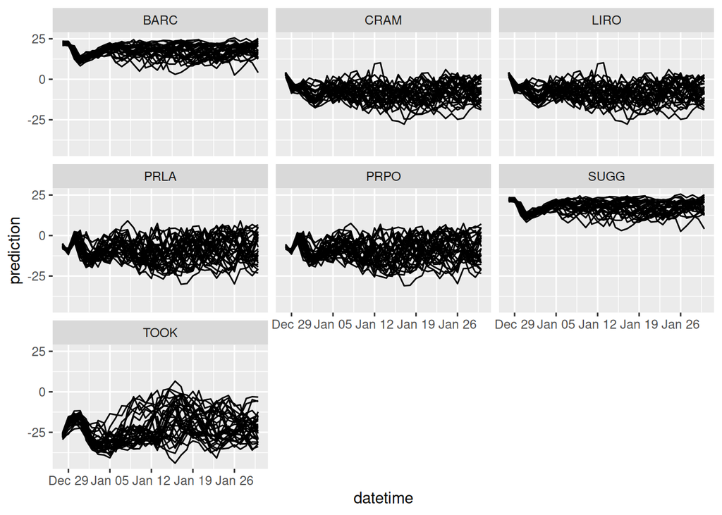

```r
targets_future <- noaa_future_daily |>
  mutate(temperature = NA,
         doy = yday(datetime))

tidymodels_forecast <- data.frame()

for(i in unique(targets_future$parameter)){
  curr_ens <- targets_future |>
    filter(parameter == i) |>
    select(-parameter)

  new_predictions <- predict(fit, new_data = curr_ens)
  curr_ens <- bind_cols(curr_ens, new_predictions) |>
    mutate(parameter = i)
  tidymodels_forecast <- bind_rows(tidymodels_forecast, curr_ens)
}

tidymodels_forecasts_EFI <- tidymodels_forecast %>%
  rename(prediction = .pred) %>%
  mutate(variable = "temperature") |>
  # For the EFI challenge we only want the forecast for future
  filter(datetime > Sys.Date()) %>%
  group_by(site_id, variable) %>%
  mutate(reference_datetime = min(datetime) - lubridate::days(1),
         family = "ensemble",
         model_id = "GAM_air_wind") %>%
  select(model_id, datetime, reference_datetime, site_id, family, parameter, variable, prediction)

tidymodels_forecasts_EFI |>
  filter(variable == "temperature") |>
  ggplot(aes(x = datetime, y = prediction, group = parameter)) +
  geom_line() +
  facet_wrap(~site_id)
```

```r
# Write the forecast to file
theme <- 'aquatics'
date <- tidymodels_forecasts_EFI$reference_datetime[1]
forecast_name_1 <- paste0(tidymodels_forecasts_EFI$model_id[1], ".csv")
forecast_file_1 <- paste(theme, date, forecast_name_1, sep = '-')
forecast_file_1
```

```
## [1] "aquatics-2025-12-27-GAM_air_wind.csv"
```

```r
if (!dir.exists('Forecasts')) {
  dir.create('Forecasts')
}

write_csv(tidymodels_forecasts_EFI, file.path('Forecasts',forecast_file_1))
```

```r
neon4cast::forecast_output_validator(file.path('Forecasts',forecast_file_1))
```

```
## Forecasts/aquatics-2025-12-27-GAM_air_wind.csv
```

```
## ✔ file has model_id column
## ✔ only one unique value in the model_id column
## ✔ forecasted variables found correct variable + prediction column
## ✔ temperature is a valid variable name
## ✔ file has correct family and parameter columns
## ✔ only one unique value in the family column
## ✔ file has site_id column
## ✔ file has datetime column
## ✔ file has correct datetime column
```

```
## ✔ file has reference_datetime column
## Forecast format is valid
```

```
## [1] TRUE
```

Change eval = TRUE if you want to submit

```r
neon4cast::submit(forecast_file = file.path('Forecasts', forecast_file_1), ask = F) # if ask = T (default), it will produce a pop-up box asking if you want to submit
```

```
## validating that file matches required standard
```

```
## Forecasts/aquatics-2025-12-27-GAM_air_wind.csv
```

```
## ✔ file has model_id column
## ✔ only one unique value in the model_id column
## ✔ forecasted variables found correct variable + prediction column
## ✔ temperature is a valid variable name
## ✔ file has correct family and parameter columns
## ✔ only one unique value in the family column
## ✔ file has site_id column
## ✔ file has datetime column
## ✔ file has correct datetime column
```

```
## ✔ file has reference_datetime column
## Forecast format is valid
##
## Thank you for submitting!
```

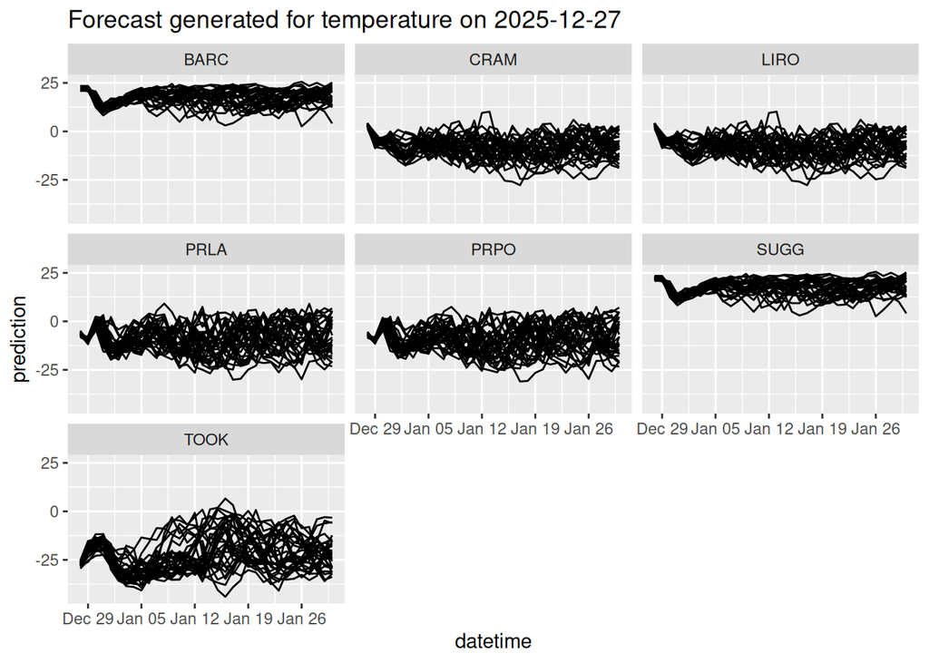

```r
tidymodels_forecasts_EFI |>
  ggplot(aes(x=datetime, y=prediction, group = parameter)) +
  geom_line() +
  facet_wrap(~site_id) +
  labs(title = paste0('Forecast generated for ', tidymodels_forecasts_EFI$variable[1], ' on ', tidymodels_forecasts_EFI$reference_datetime[1]))
```